# Lab experiments are a major source of knowledge in the social sciences

Armin Falk and James J. Heckman

September 3, 2020

# Short summary

- Brief introduction to experimental economics and their benefits
- Lab vs. Field
- Critique of critiques

# Controlled Variation

## Controlled Variation

- Economists often rely on “natural experiments”
  - Nuclear power plant closure
  - Buffer implementation
  - Sustainable, bamboo gloves vs. less expensive, non-socially responsible gloves
- A big problem is that a lot of the wanted data is unobserved, uncontrolled, and unaccounted for.

## Controlled Variation

- Lab provides a medium for the researcher to directly vary the variable of interest $X_1$, while controlling for much more of $\tilde{X}$ than with organic empirical data

# Experiment Example

- Gift-Exchange Game
- *Does Fairness Prevent Market Clearing? An Experimental Investigation* by Fehr, Kirchsteiger, Riedl
  - Does paying workers more cause them to put more effort into their job?

## Gift-Exchange Game

Problems:

- Effort is hard to measure
- Tons of external incentives/disincentives affecting effort levels
- Heterogeneity between firms, workers

## Gift-Exchange Game

In the lab, one can create mechanisms for wage and effort and can directly observe behavior

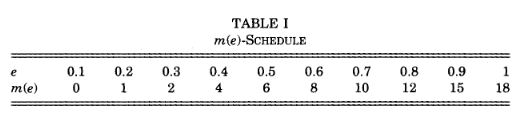

## Gift-Exchange Game

Find results that contradict theory, such as social approval, judgement biases, etc

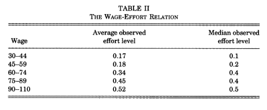

## Other Examples

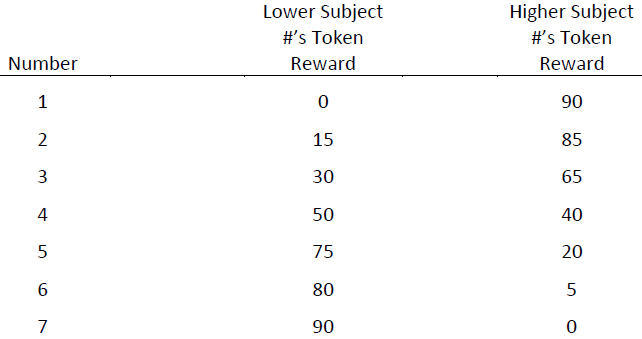

- Individuals are less socially responsible (pick the non-bamboo gloves) when their decision affects other people’s payoffs

# Lab vs. Field?

## Commonly cited characteristics

Labs:

- Tighter control over subjects
- More flexibility
- More accessible

Field:

- More “realistic”
- “Students do not represent farmers”
- Implied greater relevance to policy makers

## The true goal

The causal effect of $X_1$ on $Y$, holding fixed $\tilde{X}$.

- Labs allow researchers to fix a lot of $\tilde{X}$ and control for other.
- Field experiments might have different values $\tilde{X}'$
- “Reality” might have even different values $\tilde{X}''$. Which is a better approximation, $\tilde{X}$ or $\tilde{X}'$?
- Example: Japanese fishermen

## Use whichever one benefits you the most

Labs:

- Tighter control over $\tilde{X}$
- Useful for game theory/behavioral assumptions

Field:

- Wider and less controlled $\tilde{X}$
- Better implications for specific policies or decisions that effect diverse groups of people

# Other Critiques

## Students are not representitive

- Irrelevant for theory as it’s independent of participant pools
- For specific behavior, might be beneficial to diversify subject pool

## Stakes are trivial

- Well, what should the right level of stakes be?
- Can always just vary the stakes (Controlled Variation at work!)

## Too small sample size

- Modern experiments are run with 100+ or even 1000+ subjects
- Techniques, such as Permutation Testing (*Heckman et. al 09*), can be used to analyzed small sample and/or skewed data

## Participants are inexperienced

- Can potentially be controlled for
- Can even be analyzed (learning effects)

## Hawthorne effects

- In this day in age, we all know we’re being observed by someone/some corporation

## Self selection

- Can control for subject background in Lab
- Field might have potential for non-compliance

## Comparison with surveys

- Experiments strongly complement surveys
- Surveys are much easier to generate, but only solicit stated preference
- Experiments can validate survey results as subjects act via incentive

# Final thoughts

- Experimental work, both lab and field, provide an additional angle to control variation
- Empirical methodologies and data are compliments, not substitutes
- All trying to solve the same problem of generalizability

# Questions?

## Discussion

- Something you learned or didn’t know/fully understand before
- Are you convinced by the authors’ rhetoric?
  - Why/why not?
- As someone getting their feet wet regarding experimental economics, what are some other topics that are concerning/need clarification?
- Was the brevity of the article to its advantage or disadvantage?